# To understand why CNN is preferred over ANN for image classification

```python
    #Load packages
import numpy as np
import matplotlib.pyplot as plt
import random
import seaborn as sns
import tensorflow as tf
from sklearn.model_selection import train_test_split
from sklearn.metrics import accuracy_score, confusion_matrix, classification_report
from tensorflow.keras.datasets import cifar10
from tensorflow.keras.utils import to_categorical
from tensorflow.keras.models import Sequential
from tensorflow.keras.layers import Input, Flatten, Dense, Dropout
from tensorflow.keras.optimizers import SGD, Adam
```

```python
    # Set seeds for reproducibility
SEED = 675
np.random.seed(SEED)
random.seed(SEED)
tf.random.set_seed(SEED)
```

## Load CIFAR-10 data

```python
(x_training, y_training), (x_test, y_test) = cifar10.load_data()
```

## Normalize data

*(Code adopted from Lesson 9)

```python
    # Scale pixal values (Keep shape 32x32, 3 channels for rgb)
x_train = x_training.astype('float32') / 255.0
x_test = x_test.astype('float32') / 255.0

    # One-hot encode targets
y_train = to_categorical(y_training, 10)
y_test = to_categorical(y_test, 10)

    # Confirm shapes
print("Training set:", x_train.shape)
print("Test set:", x_test.shape)
print("Number of classes:", y_train.shape[1])
```

```
Training set: (50000, 32, 32, 3)
Test set: (10000, 32, 32, 3)
Number of classes: 10
```

## Explore data

*(Code adapted from Lesson 9 )

```
airplane: 5000 images
automobile: 5000 images
bird: 5000 images
cat: 5000 images
deer: 5000 images
dog: 5000 images
frog: 5000 images
horse: 5000 images
ship: 5000 images
truck: 5000 images
```

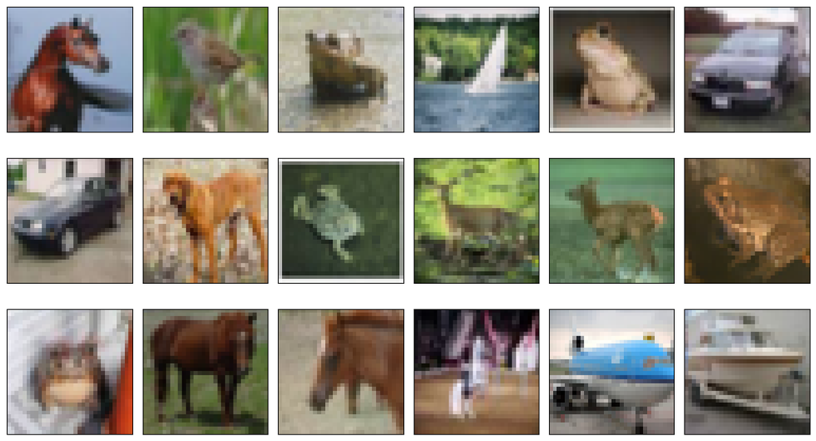

```python
    # Label names
class_names = ['airplane','automobile','bird','cat','deer','dog','frog','horse','ship','truck']

    # Show distribution of classes
    # The use of 'y_training' instead of 'y_train' prevents error:
    # trying to create list from np.float64 after one-hot encoding
unique, counts = np.unique(y_training, return_counts=True)
for i in range(len(unique)):
   print(f"{class_names[unique[i]]}: {counts[i]} images")

     # Select 18 random indices
indices = np.random.choice(np.arange(len(x_train)), 18, replace=False)

    # Display
fig, axes = plt.subplots(nrows=3, ncols=6, figsize=(12, 7))
for ax, img, label in zip(axes.ravel(), x_train[indices], y_train[indices]):
   ax.imshow(img)  # RGB
   ax.set_xticks([])  # remove x-axis ticks
   ax.set_yticks([])  # remove y-axis ticks
plt.tight_layout()
plt.show()
```

# Build simple ANN model

```python
    # Build model
ANN_model = Sequential([
    Input(shape=(32, 32, 3)),
    Flatten(),
    Dense(32, activation='relu'),
    Dense(64, activation='relu'),
    Dense(10, activation='softmax')])

ANN_model.compile(
    optimizer='adam',
    loss='categorical_crossentropy',
    metrics=['accuracy'])
```

# Train and Evaluate ANN model

```python
from tensorflow.keras.callbacks import EarlyStopping

early_stop = EarlyStopping(monitor='val_loss', patience=10, restore_best_weights=True)

history_ANN = ANN_model.fit(
    x_train, y_train,
    epochs=100,
    batch_size=256,
    validation_split=0.1,
    verbose=2,
    callbacks=[early_stop])

    # Evaluate model on test data
test_loss, test_acc = ANN_model.evaluate(x_test, y_test, verbose=0)
print(f"Test Accuracy: {test_acc:.4f}")
```

```
176/176 - 1s - 5ms/step - accuracy: 0.3796 - loss: 1.7135 - val_accuracy: 0.3606 - val_loss: 1.7506
176/176 - 1s - 6ms/step - accuracy: 0.3808 - loss: 1.7124 - val_accuracy: 0.3606 - val_loss: 1.7506
176/176 - 1s - 4ms/step - accuracy: 0.3812 - loss: 1.7110 - val_accuracy: 0.3588 - val_loss: 1.7526
176/176 - 1s - 7ms/step - accuracy: 0.3822 - loss: 1.7103 - val_accuracy: 0.3568 - val_loss: 1.7534
176/176 - 1s - 4ms/step - accuracy: 0.3828 - loss: 1.7089 - val_accuracy: 0.3596 - val_loss: 1.7512
176/176 - 1s - 8ms/step - accuracy: 0.3831 - loss: 1.7073 - val_accuracy: 0.3594 - val_loss: 1.7507
176/176 - 1s - 4ms/step - accuracy: 0.3838 - loss: 1.7056 - val_accuracy: 0.3596 - val_loss: 1.7510
176/176 - 1s - 6ms/step - accuracy: 0.3848 - loss: 1.7055 - val_accuracy: 0.3600 - val_loss: 1.7489
176/176 - 1s - 5ms/step - accuracy: 0.3849 - loss: 1.7041 - val_accuracy: 0.3578 - val_loss: 1.7498
176/176 - 1s - 7ms/step - accuracy: 0.3852 - loss: 1.7034 - val_accuracy: 0.3576 - val_loss: 1.7478
176/176 - 1s - 6ms/step - accuracy: 0.3862 - loss: 1.7019 - val_accuracy: 0.3614 - val_loss: 1.7482
176/176 - 1s - 7ms/step - accuracy: 0.3854 - loss: 1.7008 - val_accuracy: 0.3586 - val_loss: 1.7479
176/176 - 1s - 7ms/step - accuracy: 0.3857 - loss: 1.7005 - val_accuracy: 0.3608 - val_loss: 1.7471
176/176 - 1s - 7ms/step - accuracy: 0.3862 - loss: 1.6998 - val_accuracy: 0.3598 - val_loss: 1.7479
176/176 - 1s - 7ms/step - accuracy: 0.3860 - loss: 1.6996 - val_accuracy: 0.3584 - val_loss: 1.7476
176/176 - 1s - 4ms/step - accuracy: 0.3860 - loss: 1.6978 - val_accuracy: 0.3602 - val_loss: 1.7438
176/176 - 1s - 7ms/step - accuracy: 0.3861 - loss: 1.6970 - val_accuracy: 0.3592 - val_loss: 1.7451
176/176 - 1s - 7ms/step - accuracy: 0.3868 - loss: 1.6969 - val_accuracy: 0.3602 - val_loss: 1.7444
176/176 - 2s - 9ms/step - accuracy: 0.3864 - loss: 1.6966 - val_accuracy: 0.3616 - val_loss: 1.7461
176/176 - 1s - 7ms/step - accuracy: 0.3868 - loss: 1.6957 - val_accuracy: 0.3630 - val_loss: 1.7447
176/176 - 1s - 7ms/step - accuracy: 0.3873 - loss: 1.6959 - val_accuracy: 0.3628 - val_loss: 1.7439
176/176 - 1s - 7ms/step - accuracy: 0.3873 - loss: 1.6949 - val_accuracy: 0.3616 - val_loss: 1.7427
176/176 - 3s - 15ms/step - accuracy: 0.3884 - loss: 1.6944 - val_accuracy: 0.3608 - val_loss: 1.7441
176/176 - 2s - 14ms/step - accuracy: 0.3877 - loss: 1.6943 - val_accuracy: 0.3626 - val_loss: 1.7422
176/176 - 1s - 8ms/step - accuracy: 0.3888 - loss: 1.6935 - val_accuracy: 0.3614 - val_loss: 1.7450
176/176 - 2s - 12ms/step - accuracy: 0.3877 - loss: 1.6941 - val_accuracy: 0.3616 - val_loss: 1.7417
176/176 - 1s - 6ms/step - accuracy: 0.3878 - loss: 1.6930 - val_accuracy: 0.3628 - val_loss: 1.7388
176/176 - 1s - 6ms/step - accuracy: 0.3873 - loss: 1.6944 - val_accuracy: 0.3610 - val_loss: 1.7433
176/176 - 1s - 5ms/step - accuracy: 0.3862 - loss: 1.6946 - val_accuracy: 0.3640 - val_loss: 1.7397
176/176 - 1s - 8ms/step - accuracy: 0.3853 - loss: 1.6957 - val_accuracy: 0.3646 - val_loss: 1.7403
176/176 - 1s - 4ms/step - accuracy: 0.3837 - loss: 1.6970 - val_accuracy: 0.3632 - val_loss: 1.7407
176/176 - 1s - 4ms/step - accuracy: 0.3843 - loss: 1.6978 - val_accuracy: 0.3636 - val_loss: 1.7416
176/176 - 1s - 7ms/step - accuracy: 0.3846 - loss: 1.6960 - val_accuracy: 0.3660 - val_loss: 1.7435
176/176 - 1s - 4ms/step - accuracy: 0.3846 - loss: 1.6955 - val_accuracy: 0.3668 - val_loss: 1.7454
176/176 - 1s - 7ms/step - accuracy: 0.3851 - loss: 1.6941 - val_accuracy: 0.3650 - val_loss: 1.7458
176/176 - 1s - 4ms/step - accuracy: 0.3854 - loss: 1.6925 - val_accuracy: 0.3634 - val_loss: 1.7439
176/176 - 1s - 7ms/step - accuracy: 0.3856 - loss: 1.6932 - val_accuracy: 0.3636 - val_loss: 1.7443
Test Accuracy: 0.3706
```

```
Training Accuracy: 0.3856
```

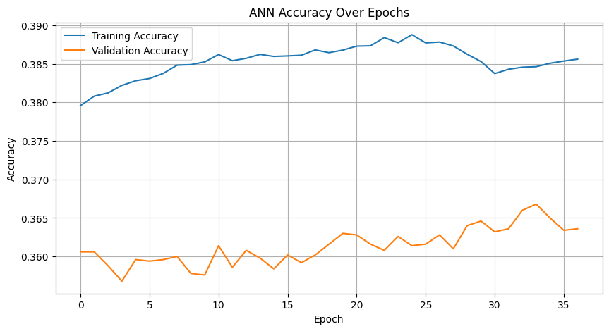

```python
    # Training accuracy
train_acc = history_ANN.history['accuracy'][-1]
print(f"Training Accuracy: {train_acc:.4f}")

    # Training improvement
plt.figure(figsize=(10, 5))
plt.plot(history_ANN.history['accuracy'], label='Training Accuracy')
plt.plot(history_ANN.history['val_accuracy'], label='Validation Accuracy')
plt.title('ANN Accuracy Over Epochs')
plt.xlabel('Epoch')
plt.ylabel('Accuracy')
plt.legend()
plt.grid(True)
plt.show()
```

# Make predictions for ANN

```
313/313 ━━━━━━━━━━━━━━━━━━━━ 0s 1ms/step
Classification Report:
              precision    recall  f1-score   support

    airplane       0.43      0.46      0.44      1000
  automobile       0.49      0.47      0.48      1000
        bird       0.19      0.13      0.16      1000
         cat       0.19      0.10      0.13      1000
        deer       0.30      0.29      0.29      1000
         dog       0.32      0.34      0.33      1000
        frog       0.37      0.49      0.42      1000
       horse       0.40      0.44      0.42      1000
        ship       0.40      0.56      0.46      1000
       truck       0.48      0.43      0.45      1000

    accuracy                           0.37     10000
   macro avg       0.36      0.37      0.36     10000
weighted avg       0.36      0.37      0.36     10000
```

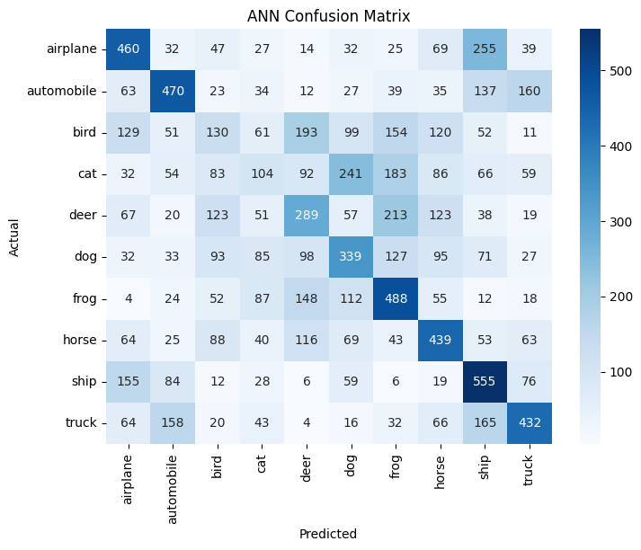

```python
    # Predictions on test data
ANN_predict = ANN_model.predict(x_test)
ANN_pred_class = np.argmax(ANN_predict, axis=1)
ANN_true_class = np.argmax(y_test, axis=1)

    # Generate classification report
print("Classification Report:")
print(classification_report(ANN_true_class, ANN_pred_class, target_names=class_names))

    # Confusion matrix
cm = confusion_matrix(ANN_true_class, ANN_pred_class)
plt.figure(figsize=(8, 6))
sns.heatmap(cm, annot=True, fmt='d', cmap='Blues',
            xticklabels=class_names,
            yticklabels=class_names)
plt.title("ANN Confusion Matrix")
plt.xlabel("Predicted")
plt.ylabel("Actual")
plt.show()
```

# Analyze ANN errors

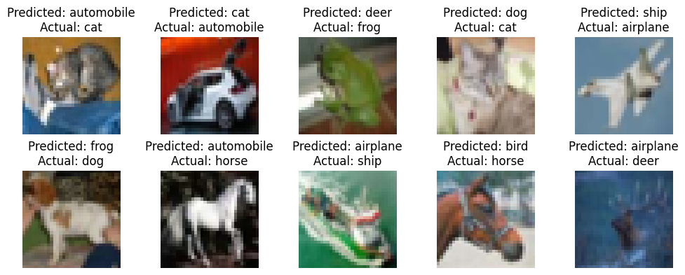

```python
    # Look at misclassified results (first 10)
misclassified_indices = np.where(ANN_pred_class != ANN_true_class)[0]
num_misclassified = 10
plt.figure(figsize=(10, 4))
for i, idx in enumerate(misclassified_indices[:num_misclassified]):
   plt.subplot(2, 5, i + 1)
   plt.imshow(x_test[idx])
   plt.title(f"Predicted: {class_names[ANN_pred_class[idx]]}\nActual: {class_names[ANN_true_class[idx]]}")
   plt.axis('off')
plt.tight_layout()
plt.show()
```

# Build a CNN model

*(Code adapted from Lesson 9 and live class examples)

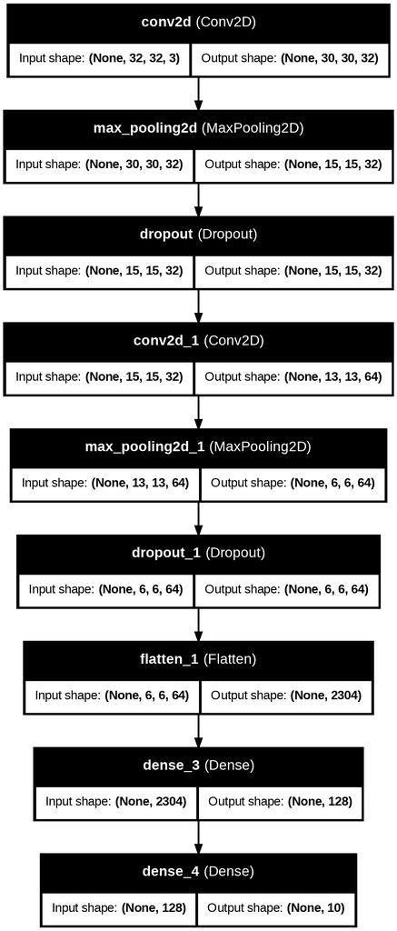

```python
from tensorflow.keras.layers import Conv2D, MaxPooling2D
from tensorflow.keras.utils import plot_model
from IPython.display import Image

    # Build model
CNN_model = Sequential([
    Input(shape=(32, 32, 3)),
    Conv2D(32, (3, 3), activation='relu'),
    MaxPooling2D(pool_size=(2, 2)),
    Dropout(0.25),
    Conv2D(64, (3, 3), activation='relu'),
    MaxPooling2D(pool_size=(2, 2)),
    Dropout(0.25),
    Flatten(),
    Dense(128, activation='relu'),
    Dense(10, activation='softmax')])

CNN_model.compile(optimizer='adam',
                  loss='categorical_crossentropy',
                  metrics=['accuracy'])

    # Display Model
plot_model(CNN_model, to_file='CNN_layers.png', show_shapes=True, show_layer_names=True)
#display(Image('CNN_layers.png'))
```

# Train and Evaluate CNN model

*(Code adapted from Lesson 9, and live class examples)

```python
    # Train model
history_CNN = CNN_model.fit(
    x_train, y_train,
    epochs=50,
    batch_size=256,
    validation_split=0.1,
    callbacks=[early_stop])

    # Evaluate on test set
test_loss_CNN, test_acc_CNN = CNN_model.evaluate(x_test, y_test)
print(f"CNN Test Accuracy: {test_acc_CNN:.4f}")
```

```
176/176 ━━━━━━━━━━━━━━━━━━━━ 10s 35ms/step - accuracy: 0.2675 - loss: 1.9869 - val_accuracy: 0.4704 - val_loss: 1.4592
176/176 ━━━━━━━━━━━━━━━━━━━━ 2s 9ms/step - accuracy: 0.4818 - loss: 1.4364 - val_accuracy: 0.5474 - val_loss: 1.2856
176/176 ━━━━━━━━━━━━━━━━━━━━ 2s 9ms/step - accuracy: 0.5416 - loss: 1.2893 - val_accuracy: 0.5908 - val_loss: 1.1930
176/176 ━━━━━━━━━━━━━━━━━━━━ 2s 9ms/step - accuracy: 0.5754 - loss: 1.2008 - val_accuracy: 0.6152 - val_loss: 1.1151
176/176 ━━━━━━━━━━━━━━━━━━━━ 2s 10ms/step - accuracy: 0.6065 - loss: 1.1237 - val_accuracy: 0.6454 - val_loss: 1.0419
176/176 ━━━━━━━━━━━━━━━━━━━━ 2s 9ms/step - accuracy: 0.6278 - loss: 1.0666 - val_accuracy: 0.6588 - val_loss: 0.9908
176/176 ━━━━━━━━━━━━━━━━━━━━ 2s 9ms/step - accuracy: 0.6444 - loss: 1.0197 - val_accuracy: 0.6694 - val_loss: 0.9587
176/176 ━━━━━━━━━━━━━━━━━━━━ 3s 11ms/step - accuracy: 0.6581 - loss: 0.9833 - val_accuracy: 0.6886 - val_loss: 0.9249
176/176 ━━━━━━━━━━━━━━━━━━━━ 2s 9ms/step - accuracy: 0.6687 - loss: 0.9465 - val_accuracy: 0.6944 - val_loss: 0.9042
176/176 ━━━━━━━━━━━━━━━━━━━━ 2s 9ms/step - accuracy: 0.6770 - loss: 0.9160 - val_accuracy: 0.7038 - val_loss: 0.8802
176/176 ━━━━━━━━━━━━━━━━━━━━ 2s 9ms/step - accuracy: 0.6899 - loss: 0.8891 - val_accuracy: 0.7172 - val_loss: 0.8558
176/176 ━━━━━━━━━━━━━━━━━━━━ 3s 9ms/step - accuracy: 0.7016 - loss: 0.8594 - val_accuracy: 0.7226 - val_loss: 0.8389
176/176 ━━━━━━━━━━━━━━━━━━━━ 2s 9ms/step - accuracy: 0.7116 - loss: 0.8315 - val_accuracy: 0.7202 - val_loss: 0.8276
176/176 ━━━━━━━━━━━━━━━━━━━━ 3s 9ms/step - accuracy: 0.7203 - loss: 0.8055 - val_accuracy: 0.7260 - val_loss: 0.8260
176/176 ━━━━━━━━━━━━━━━━━━━━ 3s 9ms/step - accuracy: 0.7278 - loss: 0.7829 - val_accuracy: 0.7324 - val_loss: 0.8131
176/176 ━━━━━━━━━━━━━━━━━━━━ 3s 10ms/step - accuracy: 0.7343 - loss: 0.7641 - val_accuracy: 0.7336 - val_loss: 0.8093
176/176 ━━━━━━━━━━━━━━━━━━━━ 2s 9ms/step - accuracy: 0.7417 - loss: 0.7425 - val_accuracy: 0.7356 - val_loss: 0.8028
176/176 ━━━━━━━━━━━━━━━━━━━━ 3s 9ms/step - accuracy: 0.7482 - loss: 0.7288 - val_accuracy: 0.7384 - val_loss: 0.7866
176/176 ━━━━━━━━━━━━━━━━━━━━ 3s 9ms/step - accuracy: 0.7557 - loss: 0.7020 - val_accuracy: 0.7406 - val_loss: 0.7729
176/176 ━━━━━━━━━━━━━━━━━━━━ 2s 9ms/step - accuracy: 0.7601 - loss: 0.6885 - val_accuracy: 0.7422 - val_loss: 0.7676
176/176 ━━━━━━━━━━━━━━━━━━━━ 2s 9ms/step - accuracy: 0.7692 - loss: 0.6580 - val_accuracy: 0.7456 - val_loss: 0.7711
176/176 ━━━━━━━━━━━━━━━━━━━━ 3s 9ms/step - accuracy: 0.7741 - loss: 0.6513 - val_accuracy: 0.7490 - val_loss: 0.7665
176/176 ━━━━━━━━━━━━━━━━━━━━ 2s 9ms/step - accuracy: 0.7820 - loss: 0.6248 - val_accuracy: 0.7490 - val_loss: 0.7657
176/176 ━━━━━━━━━━━━━━━━━━━━ 2s 9ms/step - accuracy: 0.7867 - loss: 0.6144 - val_accuracy: 0.7446 - val_loss: 0.7706
176/176 ━━━━━━━━━━━━━━━━━━━━ 3s 9ms/step - accuracy: 0.7932 - loss: 0.5969 - val_accuracy: 0.7434 - val_loss: 0.7774
313/313 ━━━━━━━━━━━━━━━━━━━━ 2s 5ms/step - accuracy: 0.7213 - loss: 0.8034
CNN Test Accuracy: 0.7212
```

```
Training Accuracy: 0.7928
```

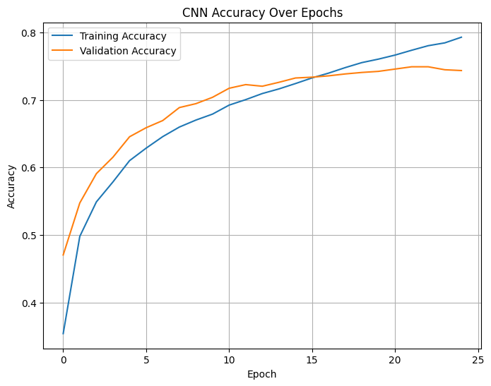

```python
   # Training accuracy
cnn_acc = history_CNN.history['accuracy'][-1]
print(f"Training Accuracy: {cnn_acc:.4f}")

    # Training curve
plt.figure(figsize=(8, 6))
plt.plot(history_CNN.history['accuracy'], label='Training Accuracy')
plt.plot(history_CNN.history['val_accuracy'], label='Validation Accuracy')
plt.title('CNN Accuracy Over Epochs')
plt.xlabel('Epoch')
plt.ylabel('Accuracy')
plt.legend()
plt.grid(True)
plt.show()
```

# Predictions for CNN model

```
313/313 ━━━━━━━━━━━━━━━━━━━━ 1s 2ms/step
Predicted Probabilities: [0.00456366 0.00337384 0.00587268 0.78505695 0.00103472 0.16001904
 0.02890207 0.00228727 0.00692482 0.00196498]
Predicted Class:         3
Actual Class:            3
CNN Classification Report:
              precision    recall  f1-score   support

    airplane       0.80      0.75      0.77      1000
  automobile       0.79      0.86      0.83      1000
        bird       0.63      0.60      0.61      1000
         cat       0.60      0.42      0.50      1000
        deer       0.67      0.66      0.67      1000
         dog       0.60      0.69      0.64      1000
        frog       0.69      0.86      0.77      1000
       horse       0.80      0.76      0.78      1000
        ship       0.80      0.86      0.83      1000
       truck       0.82      0.76      0.79      1000

    accuracy                           0.72     10000
   macro avg       0.72      0.72      0.72     10000
weighted avg       0.72      0.72      0.72     10000
```

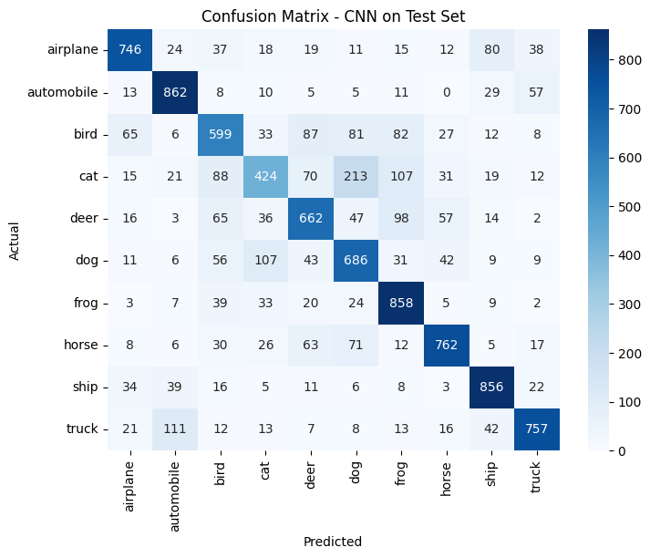

```python
    # Predict on test data
CNN_pred = CNN_model.predict(x_test)
pred_CNN_class = np.argmax(CNN_pred, axis=1)

    # Convert true test labels from one-hot to class indices
Final_CNN_class = np.argmax(y_test, axis=1)

    # Display predictions
print("Predicted Probabilities:", CNN_pred[0])
print("Predicted Class:        ", pred_CNN_class[0])
print("Actual Class:           ", Final_CNN_class[0])

    # Classification report
print("CNN Classification Report:")
print(classification_report(Final_CNN_class, pred_CNN_class, target_names=class_names))

    # Confusion matrix
CNN_cm = confusion_matrix(Final_CNN_class, pred_CNN_class)
plt.figure(figsize=(8, 6))
sns.heatmap(CNN_cm, annot=True, fmt='d', cmap='Blues',
            xticklabels=class_names, yticklabels=class_names)
plt.title("Confusion Matrix - CNN on Test Set")
plt.xlabel("Predicted")
plt.ylabel("Actual")
plt.show()
```

# Analyze CNN errors

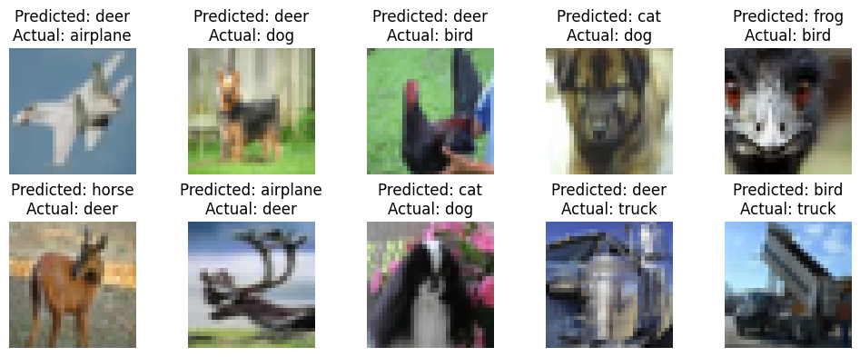

```python
    # Look at misclassified results (first 10)
misclassified_indices = np.where(pred_CNN_class != Final_CNN_class)[0]

num_misclassified = 10
plt.figure(figsize=(10, 4))
for i, idx in enumerate(misclassified_indices[:num_misclassified]):
   plt.subplot(2, 5, i + 1)
   plt.imshow(x_test[idx])
   plt.title(f"Predicted: {class_names[pred_CNN_class[idx]]}\nActual: {class_names[Final_CNN_class[idx]]}")
   plt.axis('off')
plt.tight_layout()
plt.show()
```

# Compare the models

[figure not shown]

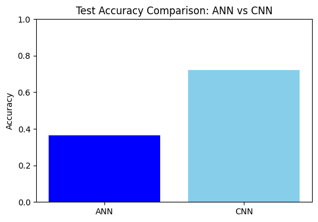

```python
    # Validation accuracy
plt.figure(figsize=(10, 5))
plt.plot(history_ANN.history['val_accuracy'], label='ANN Accuracy')
plt.plot(history_CNN.history['val_accuracy'], label='CNN Accuracy')
plt.title('CNN vs ANN Accuracy Over Epochs')
plt.xlabel('Epoch')
plt.ylabel('Accuracy')
plt.legend()
plt.grid(True)
plt.show()
print()

    # Testing accuracy
plt.figure(figsize=(6, 4))
plt.bar(['ANN', 'CNN'], [test_acc, test_acc_CNN], color=['blue', 'skyblue'])
plt.ylim(0, 1)
plt.title('Test Accuracy Comparison: ANN vs CNN')
plt.ylabel('Accuracy')
plt.show()
```

### ANN vs. CNN Comparison

**Model Structures**

**Validation Accuracy**

- ANN Validation Accuracy: 0.36
- CNN Validation Accuracy: 0.74

**Final Accuracy**

- ANN Test Accuracy: 0.37
- CNN Test Accuracy: 0.72

**Observations**

**Conclusion**

- ANNs are faster and are still useful for low-dimensional data, but they lack the inductive bias that makes CNNs effective for visual patterns.
- CNNs are the preferred architecture for image classification tasks like CIFAR-10.

**Next steps**

- Correcting overfitting and increasing accuracy should be accomplished with some hypertuning, but the computational time was markedly longer using CNN.
- I attempted to use a TPU, but was unable to connect. Running the models with a TPU runtime would aid in fine tuning the CNN.

***Resources:**  
*Zoom session* 4/26/2025, ANA675, National University

*Lesson 9* - convolutional-neural-networks-in-python.pdf, ANA675, National University

*Deep Learning* Glassner, A. (2021). "Deep Learning" No Scratch Press. CHAPTERS 13-15.